# Moneyball

A look into the lesson made in baseball through the movie "Moneyball" with setup tutorial.  
By Ryan Park

# Outline

1. Background
2. Setup Requirements
3. Data Collection
4. Part 1: Wrangling
5. Part 2: Exploratory Data Analysis
6. Part 3: Data transformations
7. Conclusion

**Feel free to use the outline above to skip around the tutorial.**

# Background

We'll be looking at data about teams in Major League Baseball from 1990 - 2014.

[Major League Baseball](https://en.wikipedia.org/wiki/Major_League_Baseball) is a professional baseball league, where teams pay players to play baseball. The goal of each team is to win as many games out of a 162 game season as possible. Teams win games by scoring more runs (getting more points) than their adversary.

In principle, better players are costlier, so teams that want good players need to spend more money. Teams that spend the most, frequently win the most. So, the question is, how can a team that can't spend so much win?

The basic idea that the [Oakland A's](https://en.wikipedia.org/wiki/Oakland_Athletics) (and other teams) used is to redefine what makes a player good, such as figuring out what player characteristics translated into wins. Once they realized that teams were not really pricing players using these characteristics, they could exploit this to pay for undervalued players, players that were good according to their metrics, but were not recognized as such by other teams, and therefore not as expensive.

You can get more information about this period in baseball history from:

[Moneyball Wiki](https://en.wikipedia.org/wiki/Moneyball)

[Moneyball Book](http://www.amazon.com/Moneyball-The-Winning-Unfair-Game/dp/0393324818)

[Moneyball Movie](http://www.imdb.com/title/tt1210166/)

# Setup Requirements

Before we start doing anything too fancy, we must first make sure we have the right tools and files to get the job done.

1. We will be using the latest version of Python 3 and Jupyter Notebook.

> If you don't have Python 3 and/or Jupyter Notebook here's a couple links to help you out.  
> Python 3 Download: [Python 3](https://www.python.org/downloads/)  
> Anaconda Download: [Anaconda](https://www.anaconda.com/products/individual)  
> Platform Downloads (read both first): [Jupyter Notebook part 1/2](https://www.geeksforgeeks.org/how-to-install-jupyter-notebook-in-windows/) and [Jupyter Notebook part 2/2](https://jupyter.org/install)
1. We will need the following libraries from Python 3:

> Installing Python 3 and Anaconda should already download these for you so there should be no worries in accessing them (for now).
> - sqlite3
> - pandas
> - numpy
> - matplotlib.plyplot
1. Download the sqlite file on baseball teams, players, and seasons curated by Sean Lahman.

> Instructions to gettting the data is as followed:
> 1. Click on this url: [lanham2014](https://github.com/jknecht/baseball-archive-sqlite/raw/master/lahman2014.sqlite).
> 2. Once automatically downloaded, move the "lanham2014.sqlite" file to the same project folder for access.

# Data Collection

### About the Data

We'll be using data from a useful database on baseball teams, players, and seasons curated by Sean Lahman available at http://www.seanlahman.com/baseball-archive/statistics/.

The database is available as a sqlite database https://github.com/jknecht/baseball-archive-sqlite, which will be used for this project.

> Sqlite is a light-weight, file-based database management system that is well suited for small projects and prototypes.

You can read more about the dataset here: http://seanlahman.com/files/database/readme2014.txt.

### Importing Libraries

```python
import sqlite3 as sql
import pandas as pd
import numpy as np
import matplotlib.pyplot as plt
```

# Part 1: Wrangling

Access sqlite file to extract the Salaries and Teams tables of the database.

```python
sqlite_file = 'lahman2014.sqlite'
conn = sql.connect(sqlite_file)
```

**Both separate dataframes will be grouped by team and year and ordered (ascending) by team.**

Create dataframe from the Salaries table using data involving team, year, and total_payroll (sum of salaries).

```python
salary_query = "SELECT teamID as team, yearID as year, sum(salary) as total_payroll FROM Salaries GROUP BY teamId, yearID ORDER BY teamID"
team_salaries = pd.read_sql(salary_query, conn)
```

Create dataframe from the Teams table using data involving team, year, wins, games, winning_percentage (wins / games * 100), and franchise.

```python
winning_query = "SELECT teamID as team, yearID as year, W as wins, G as games, W * 100.0 / G as winning_percentage, franchID as franchise FROM Teams GROUP BY teamID, yearID ORDER BY teamID"
team_winnings = pd.read_sql(winning_query, conn)
```

Join both dataframes into one by team and year.  
By performing Inner Join, any missing data between both dataframes via team and year will be ignored.

```python
team_results = pd.merge(team_salaries, team_winnings, how='inner', on=['team','year'])

# team results dataframe
team_results
```

|  | team | year | total_payroll | wins | games | winning_percentage | franchise |
| --- | --- | --- | --- | --- | --- | --- | --- |
| 0 | ANA | 1997 | 31135472.0 | 84 | 162 | 51.851852 | ANA |
| 1 | ANA | 1998 | 41281000.0 | 85 | 162 | 52.469136 | ANA |
| 2 | ANA | 1999 | 55388166.0 | 70 | 162 | 43.209877 | ANA |
| 3 | ANA | 2000 | 51464167.0 | 82 | 162 | 50.617284 | ANA |
| 4 | ANA | 2001 | 47535167.0 | 75 | 162 | 46.296296 | ANA |
| ... | ... | ... | ... | ... | ... | ... | ... |
| 853 | WAS | 2010 | 61400000.0 | 69 | 162 | 42.592593 | WSN |
| 854 | WAS | 2011 | 63856928.0 | 80 | 161 | 49.689441 | WSN |
| 855 | WAS | 2012 | 80855143.0 | 98 | 162 | 60.493827 | WSN |
| 856 | WAS | 2013 | 113703270.0 | 86 | 162 | 53.086420 | WSN |
| 857 | WAS | 2014 | 131983680.0 | 96 | 162 | 59.259259 | WSN |

858 rows × 7 columns

# Part 2: Exploratory Data Analysis

## 2.a Payroll Distribution

Create new table conditioned from 1990 to 2014.

```python
data_condition = team_results[team_results.year > 1989]
data_condition = data_condition[data_condition.year < 2015]
```

Create a table that displays the total payroll of each team from 1990 to 2014.

```python
payroll_data = data_condition.pivot(index = 'year', columns = 'team', values = 'total_payroll')
```

Plot line graphs of each team's total payroll from 1990 to 2014.

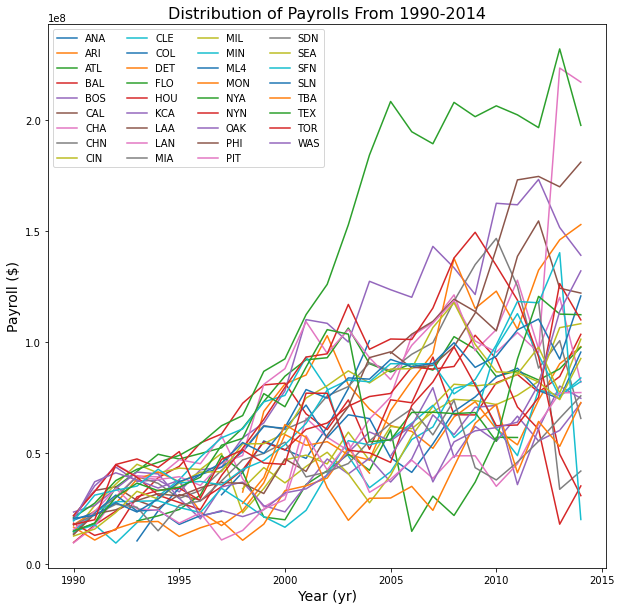

```python
plt.figure(figsize = (10, 10))
for column in (payroll_data.columns):
    plt.plot(payroll_data[column], label = column)

# label the graph with a title, x-axis, y-axis, and a legend
plt.title("Distribution of Payrolls From 1990-2014", fontsize = 16)
plt.xlabel("Year (yr)", fontsize = 14)
plt.ylabel("Payroll ($)", fontsize = 14)
plt.legend(ncol = 4)

plt.show()
```

### Analysis

Based on the graph above, payrolls across teams had increased over time between 1990 to 2014. Not only that, each team experienced a greater variance in their payrolls, which makes it more difficult to sprecifically predit how much they'll spend in the future. Across all the teams, there's a very high range of payrolls, as viewed by the increasing spread between each line, but there is a clear statement that teams are spending more on average over time.

## 2.b Average Payrolls

Using the data from above, the average payroll of all team is calculated.

```python
avg_payrolls = payroll_data.copy()
for index, row in avg_payrolls.iterrows():
    avg_payrolls.at[index, 'avg_payroll'] = row.mean()

avg_payrolls = avg_payrolls[['avg_payroll']]
```

Plot a line graph of the average payroll of every team from 1990 to 2014.

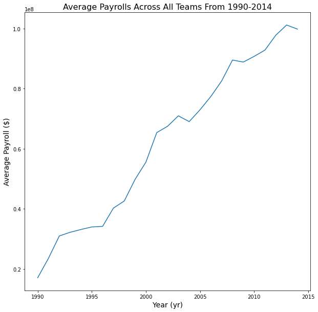

```python
plt.figure(figsize = (10, 10))
plt.plot(avg_payrolls['avg_payroll'])

# label the graph with a title, x-axis, and y-axis
plt.title("Average Payrolls Across All Teams From 1990-2014", fontsize = 16)
plt.xlabel("Year (yr)", fontsize = 14)
plt.ylabel("Average Payroll ($)", fontsize = 14)
plt.show()
```

## 2.c Correlation Between Payroll & Winning Percentage

```python
new_data = data_condition.copy()

periods = ['1990 - 1994','1995 - 1999','2000 - 2004','2005 - 2009','2010 - 2014']
new_data['period'] = pd.cut(new_data['year'], bins = 5, right = False, labels = periods)
```

For each period, plot a scatterplot that represents the average winning percentage (y-axis) over average payroll (x-axis) of all teams that competed that period.

Each point on the graph will be labeled and a regression line will be added for future interpretation.

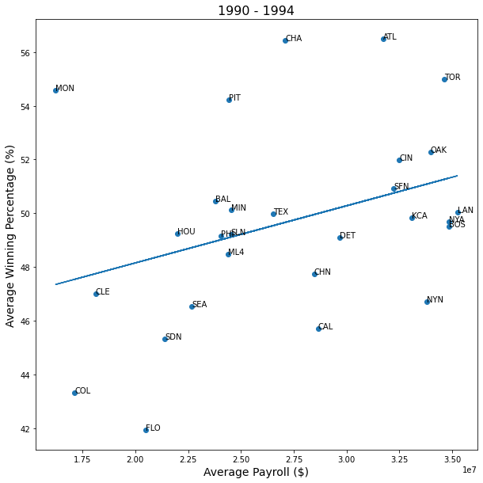

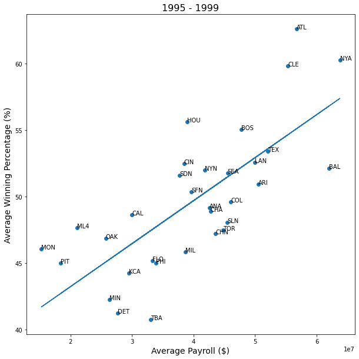

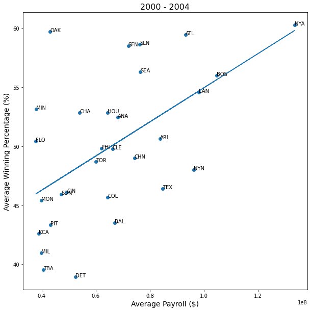

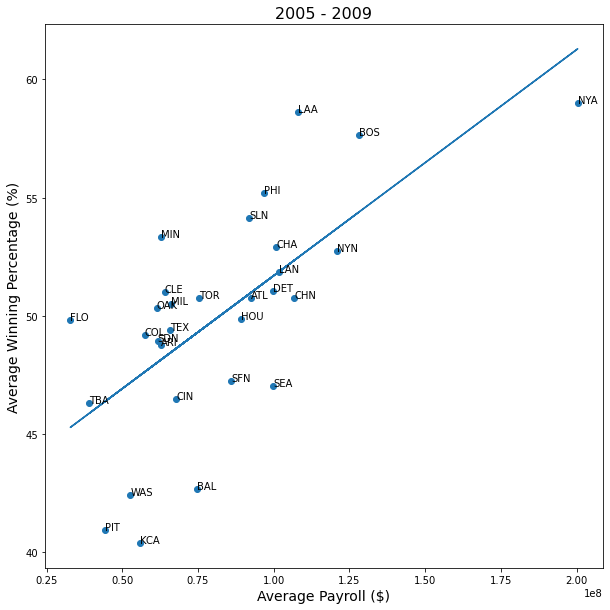

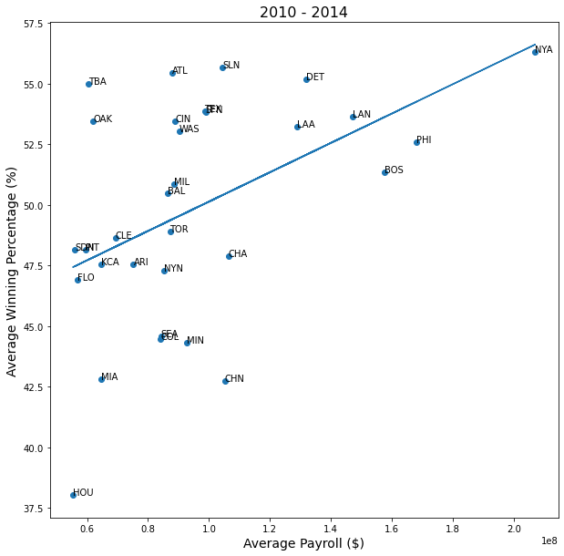

```python
# 5 periods
for period in periods:
    # select a specific period throughout the table
    section_data = new_data[new_data.period == period]

    # get the values of each teams average payroll and average winnings
    avg_payroll = section_data.groupby('team')['total_payroll'].mean().values
    avg_win = section_data.groupby('team')['winning_percentage'].mean().values

    # create a dataframe of both values
    table = pd.DataFrame({'team': section_data['team'].drop_duplicates().values, 'avg_payroll': avg_payroll, 'avg_win': avg_win})

    # scatterplot w/ regression line
    plt.figure(figsize = (10, 10))
    m, b = np.polyfit(table['avg_payroll'], table['avg_win'], 1)
    plt.plot(table['avg_payroll'], m * table['avg_payroll'] + b)
    plt.scatter(table['avg_payroll'], table['avg_win'])

    # label each point on the graph with their respective team
    for index, txt in enumerate(table['team']):
        plt.annotate(txt, (table.at[index, 'avg_payroll'], table.at[index, 'avg_win']))

    # label the graph with a title, x-axis, and y-axis
    plt.title(period, fontsize = 16)
    plt.xlabel("Average Payroll ($)", fontsize = 14)
    plt.ylabel("Average Winning Percentage (%)", fontsize = 14)
    plt.show()
```

### Analysis

In all five periods, Oakland A stayed above the regression line, which indicates that they've been efficient in spending money for wins. On top of that, Oakland A generally doesn't spend that much compared to other teams above the regression line. Oakland A would especially be very effective in spending less but still winning more during 2000 - 2004.

# Part 3: Data transformations

## 3.a Standardizing Across Years

By finding the average payroll and standard deviation of all teams in a given year, the standardized payroll of a team from a particular year is calculated and stored in the main dataframe.

```python
avg_payroll = new_data.groupby('year')['total_payroll'].mean()
std = new_data.groupby('year')['total_payroll'].std()

for index, row in new_data.iterrows():
    new_data.at[index, 'stdz_payroll'] = (row['total_payroll'] - avg_payroll[row['year']]) / std[row['year']]

# main dataframe
new_data
```

|  | team | year | total_payroll | wins | games | winning_percentage | franchise | period | stdz_payroll |
| --- | --- | --- | --- | --- | --- | --- | --- | --- | --- |
| 0 | ANA | 1997 | 31135472.0 | 84 | 162 | 51.851852 | ANA | 1995 - 1999 | -0.698639 |
| 1 | ANA | 1998 | 41281000.0 | 85 | 162 | 52.469136 | ANA | 1995 - 1999 | -0.086369 |
| 2 | ANA | 1999 | 55388166.0 | 70 | 162 | 43.209877 | ANA | 1995 - 1999 | 0.271410 |
| 3 | ANA | 2000 | 51464167.0 | 82 | 162 | 50.617284 | ANA | 2000 - 2004 | -0.190214 |
| 4 | ANA | 2001 | 47535167.0 | 75 | 162 | 46.296296 | ANA | 2000 - 2004 | -0.721244 |
| ... | ... | ... | ... | ... | ... | ... | ... | ... | ... |
| 853 | WAS | 2010 | 61400000.0 | 69 | 162 | 42.592593 | WSN | 2010 - 2014 | -0.769040 |
| 854 | WAS | 2011 | 63856928.0 | 80 | 161 | 49.689441 | WSN | 2010 - 2014 | -0.709594 |
| 855 | WAS | 2012 | 80855143.0 | 98 | 162 | 60.493827 | WSN | 2010 - 2014 | -0.459099 |
| 856 | WAS | 2013 | 113703270.0 | 86 | 162 | 53.086420 | WSN | 2010 - 2014 | 0.257062 |
| 857 | WAS | 2014 | 131983680.0 | 96 | 162 | 59.259259 | WSN | 2010 - 2014 | 0.704160 |

728 rows × 9 columns

For each period, plot a scatterplot that represents the average winning percentage (y-axis) over standardized payroll (x-axis) of all teams that competed that period.

Each point on the graph will be labeled and a regression line will be added for future interpretation.

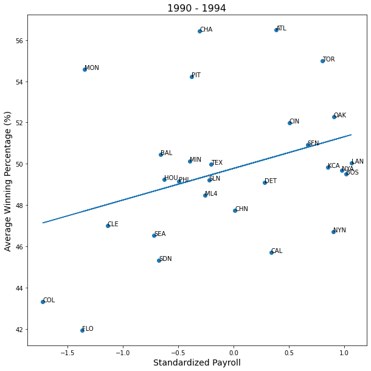

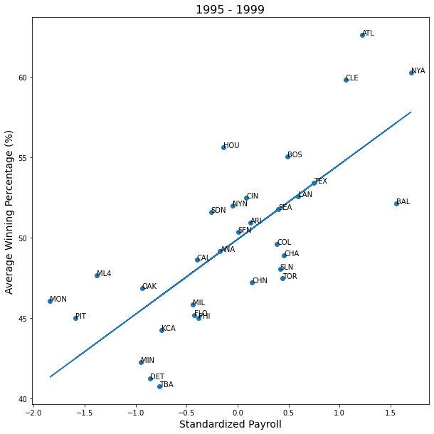

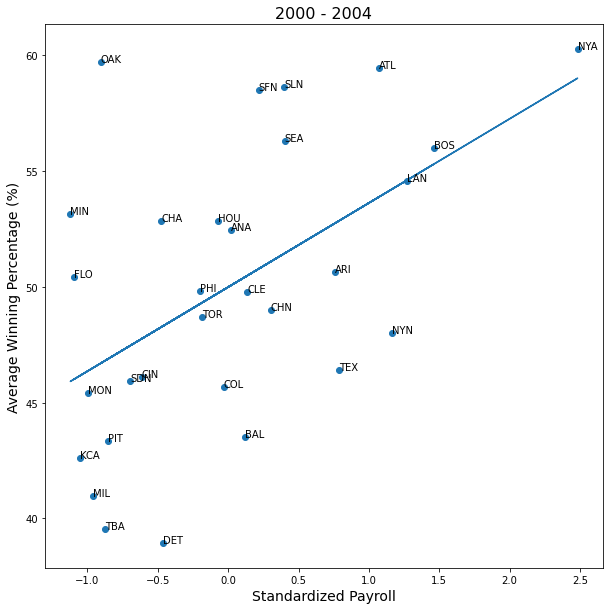

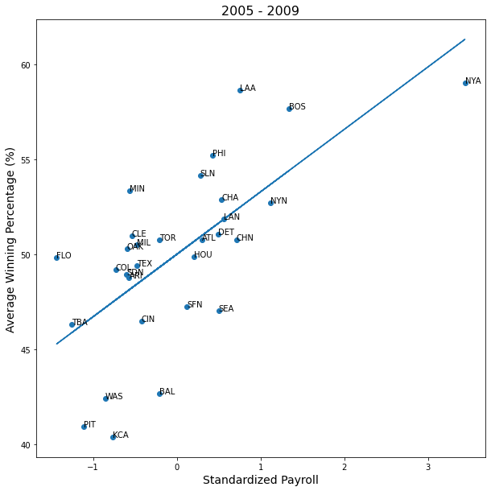

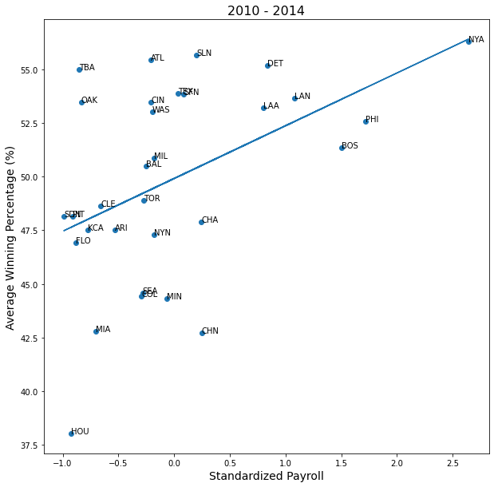

```python
# 5 periods
for period in periods:
    # select a specific period throughout the table
    section_data = new_data[new_data.period == period]

    # get the values of each teams standardized payroll and average winnings
    stdz_payroll = section_data.groupby('team')['stdz_payroll'].mean().values
    avg_win = section_data.groupby('team')['winning_percentage'].mean().values

    # create a dataframe of both values
    table = pd.DataFrame({'team': section_data['team'].drop_duplicates().values, 'stdz_payroll': stdz_payroll, 'avg_win': avg_win})

    # scatterplot w/ regression line
    plt.figure(figsize = (10, 10))
    m, b = np.polyfit(table['stdz_payroll'], table['avg_win'], 1)
    plt.plot(table['stdz_payroll'], m * table['stdz_payroll'] + b)
    plt.scatter(table['stdz_payroll'], table['avg_win'])

    # label each point on the graph with their respective team
    for index, txt in enumerate(table['team']):
        plt.annotate(txt, (table.at[index, 'stdz_payroll'], table.at[index, 'avg_win']))

    # label the graph with a title, x-axis, and y-axis
    plt.title(period, fontsize = 16)
    plt.xlabel("Standardized Payroll", fontsize = 14)
    plt.ylabel("Average Winning Percentage (%)", fontsize = 14)
    plt.show()
```

### Analysis

Both plots from above and Section 2.c have an increasing regression line. With this new information, it can be said that the more standard deviations above the average payroll of all teams spent will result in more winnings. In other words, the higher above the average payroll of all teams spent, the higher the winnings.

To touch back on Oakland A's example from 2000 - 20004, even though they spent almost one standard deviation below the average payroll of all the teams that period, they were still able to achieve a high winning percentage than almost all the teams.

## 3.b Expected Wins

Make a scatter plot of the winning percentage (y-axis) over standardized payroll (x-axis) from 1990 to 2014 with a regression line.

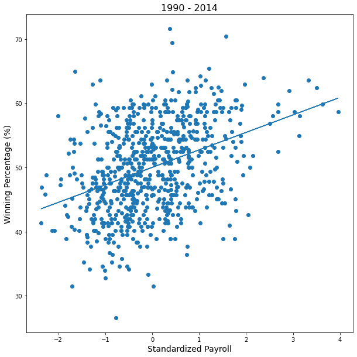

```python
# scatterplot w/ regression line
plt.figure(figsize = (10, 10))
m, b = np.polyfit(new_data['stdz_payroll'], new_data['winning_percentage'], 1)
plt.plot(new_data['stdz_payroll'], m * new_data['stdz_payroll'] + b)
plt.scatter(new_data['stdz_payroll'], new_data['winning_percentage'])

# label the graph with a title, x-axis, and y-axis
plt.title("1990 - 2014", fontsize = 16)
plt.xlabel("Standardized Payroll", fontsize = 14)
plt.ylabel("Winning Percentage (%)", fontsize = 14)
plt.show()
```

## 3.c Spending Efficiency

Create two columns containing the expected win percentage and spending efficiency of each team from a particular year.

```python
for index, row in new_data.iterrows():
    expected_win_percentage = new_data.at[index, 'expected_win_percentage'] = 50 + (2.5 * row['stdz_payroll'])
    new_data.at[index, 'spend_efficiency'] = row['winning_percentage'] - expected_win_percentage

new_data
```

|  | team | year | total_payroll | wins | games | winning_percentage | franchise | period | stdz_payroll | expected_win_percentage | spend_efficiency |
| --- | --- | --- | --- | --- | --- | --- | --- | --- | --- | --- | --- |
| 0 | ANA | 1997 | 31135472.0 | 84 | 162 | 51.851852 | ANA | 1995 - 1999 | -0.698639 | 48.253402 | 3.598450 |
| 1 | ANA | 1998 | 41281000.0 | 85 | 162 | 52.469136 | ANA | 1995 - 1999 | -0.086369 | 49.784077 | 2.685059 |
| 2 | ANA | 1999 | 55388166.0 | 70 | 162 | 43.209877 | ANA | 1995 - 1999 | 0.271410 | 50.678524 | -7.468647 |
| 3 | ANA | 2000 | 51464167.0 | 82 | 162 | 50.617284 | ANA | 2000 - 2004 | -0.190214 | 49.524464 | 1.092820 |
| 4 | ANA | 2001 | 47535167.0 | 75 | 162 | 46.296296 | ANA | 2000 - 2004 | -0.721244 | 48.196891 | -1.900595 |
| ... | ... | ... | ... | ... | ... | ... | ... | ... | ... | ... | ... |
| 853 | WAS | 2010 | 61400000.0 | 69 | 162 | 42.592593 | WSN | 2010 - 2014 | -0.769040 | 48.077399 | -5.484807 |
| 854 | WAS | 2011 | 63856928.0 | 80 | 161 | 49.689441 | WSN | 2010 - 2014 | -0.709594 | 48.226016 | 1.463425 |
| 855 | WAS | 2012 | 80855143.0 | 98 | 162 | 60.493827 | WSN | 2010 - 2014 | -0.459099 | 48.852252 | 11.641575 |
| 856 | WAS | 2013 | 113703270.0 | 86 | 162 | 53.086420 | WSN | 2010 - 2014 | 0.257062 | 50.642655 | 2.443765 |
| 857 | WAS | 2014 | 131983680.0 | 96 | 162 | 59.259259 | WSN | 2010 - 2014 | 0.704160 | 51.760400 | 7.498860 |

728 rows × 11 columns

Create a line plot of selected teams' spending efficiency from 1990 - 2014.

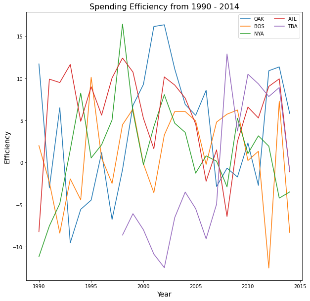

```python
eff = new_data.pivot(index = 'year', columns = 'team', values = 'spend_efficiency')
teams = ['OAK', 'BOS', 'NYA', 'ATL', 'TBA']

# Create line plots
plt.figure(figsize = (10, 10))
for team in teams:
    plt.plot(eff[team], label = team)

# label the graph with a title, x-axis, y-axis, and legend
plt.title("Spending Efficiency from 1990 - 2014", fontsize = 16)
plt.xlabel("Year", fontsize = 14)
plt.ylabel("Efficiency", fontsize = 14)
plt.legend(ncol = 2)
plt.show()
```

### Concluding Analysis

Although spending more on players will predictably result in more wins, concluded from sections 2.c and 3.a, it doesn't necessarily mean that it's efficient all the time. This can be seen by the high range of fluctations of efficiency from the graph above and, most notably, Oakland's efficiency during the Moneyball period (2000 - 2005).

Oakland's efficiency was the highest for a considerable time during the Moneyball period. This goes to show that effectively spending money on the right players rather than spending more money overall can go a long way and end up bring the team more wins.